# QTM 151 - Introduction to Statistical Computing II

Lecture 12 - Application 03: Linear Models

Danilo Freire

danilo.freire@emory.edu

Emory University

09 October, 2024

# Hello, everyone! How are you doing? 😊

## Linear Models

### How to fit and interpret linear models in Python

- Today we will learn how to run a linear regression using the [`statsmodels` library](https://www.statsmodels.org/stable/index.html) in Python
- [Linear models](https://en.wikipedia.org/wiki/Linear_regression) (also known as [ordinary least squares](https://en.wikipedia.org/wiki/Ordinary_least_squares)) are the most common type of regression analysis
  - They are used to predict the value of a dependent variable based on one or more independent variables
  - As the name implies, the relationship between the dependent variable and the independent variables is assumed to be linear (i.e., a straight line)
- But don’t worry: if you haven’t had statistics before, I will explain everything you need to know (no maths required, trust me! 😅)

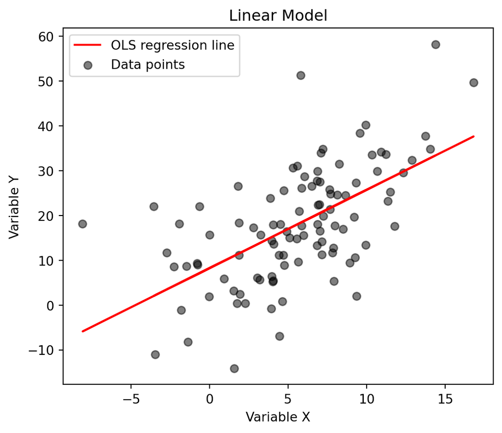

```python
# Import libraries
import numpy as np
import pandas as pd
import statsmodels.api as sm
import matplotlib.pyplot as plt

# Create a pandas DataFrame
np.random.seed(151)
x = np.random.normal(loc = 5, scale = 5, size = 100)
y = 1 + 2*x + np.random.normal(loc = 5, scale = 10, size = 100)
df = pd.DataFrame({'y': y, 'x': x})

# Estimate OLS
X = sm.add_constant(x)
model = sm.OLS(y, X).fit()
predictions = model.predict(X)

# Create graph
plt.figure(figsize = (6, 5))
plt.plot(x, predictions, color = 'red', label = 'OLS regression line')
plt.scatter(x = df.x, y = df.y, color = "black", alpha= 0.5, label = 'Data points')

# Add labels and legend
plt.xlabel('Variable X')
plt.ylabel('Variable Y')
plt.title('Linear Model')
plt.legend()
plt.show()
```

## Import and install libraries

- First, let’s import the libraries we have seen so far

```python
import numpy as np
import pandas as pd
import matplotlib.pyplot as plt
```

- Now, let’s install the `statsmodels` library
- According to the [Anaconda website](https://docs.anaconda.com/anaconda/allpkglists/2024.06-1/), `statsmodels` is already included in the distribution, but you can install it using `conda` or `pip`.
- Mac and Linux users can run the following command in the terminal:

```bash
conda install statsmodels
```

- Windows users can do the following:
  - Open the Anaconda Prompt then type `conda install statsmodels` and press Enter

[figure not shown]

- `statsmodels` is the go-to library for statistical modelling in Python
- It has models for linear regression, time series analysis, and much more
- It works well with `pandas` and `numpy` and [even supports `R`-style formulas](https://www.statsmodels.org/stable/example_formulas.html)
  - `model = smf.ols(formula = 'Dependent ~ Independent01 + Independent02', data=df)`
- We will use it to estimate our linear model

## Generate simulated data

- Let’s generate some simulated data to illustrate how linear models work 😊📈
- First, let’s create an empty DataFrame

```python
dataset = pd.DataFrame()
```

- Now, let’s create two random variables of size 50

```python
n = 50
np.random.seed(42)
dataset["x"] = np.random.normal(loc = 0,scale = 1, size = n)
dataset["e"] = np.random.normal(loc = 0,scale = 1, size = n)
```

- Let me explain what we’re doing here 🤓
  - `x` is the independent variable, which we will use to predict the dependent variable `y`
  - `e` is the error term, which represents the noise in the data
- Why do we include the error term?
  - Because in real life, we don’t have perfect data
  - The error term is what makes the relationship between `x` and `y` not perfect

## Generate simulated data

- Now, let’s create data from the linear model
- The model will be $y = b_0 + b_1 x + e$, where $b_0 = 1, b_1 = 2.$
- $b_0$ is the intercept, $b_1$ is the slope, and $e$ is the error term
- Let’s create the dependent variable `y` using the formula above

```python
# Create the dependent variable
# y = 1 + 2*x + e
b0 = 1
b1 = 2

dataset["y"] = b0 + b1 * dataset["x"] + dataset["e"]
```

- Then, let’s compute the line of best fit

```python
# Line of best fit
dataset["p"] = b0 + b1*dataset["x"]
dataset.head(3)
```

|  | x | e | y | p |
| --- | --- | --- | --- | --- |
| 0 | 0.496714 | 0.324084 | 2.317512 | 1.993428 |
| 1 | -0.138264 | -0.385082 | 0.338389 | 0.723471 |
| 2 | 0.647689 | -0.676922 | 1.618455 | 2.295377 |

## Visualising the data

- Now, let’s plot the data and the line of best fit

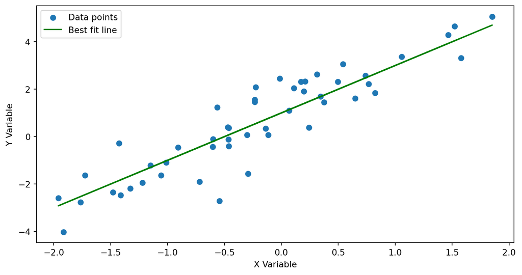

```python
# Plot the data
plt.scatter(x = dataset["x"], y = dataset["y"])
plt.plot(dataset["x"], dataset["p"], color = 'green')

plt.xlabel("X Variable")
plt.ylabel("Y Variable")
plt.legend(labels = ["Data points", "Best fit line"])
plt.show()
```

## Try it yourself! 🚀

- Create a new dataset called `subset_above2`
- Subset records with $y \ge 2$ using `.query()`
- Count the original rows with `len(dataset)`
- Count the subsetted rows: `len(subset_above2)`
- Compute the proportion of subsetted observations
- Solution: Appendix 01

## Try it yourself! 🚀

- Store the sample mean of $y$ as `ybar`
- Compute the standard deviation of $y$ as `stdv_sample`
- Use `.query()` to subset observations that satisfy

$$abs\left(y - ybar \right) \le stdv\_sample$$

- HINT: Use `.mean()` and `.std()`
- HINT: Use the globals `@xbar`, `@stdv_sample`
- Solution: Appendix 02

Note: `.abs()` is a `pandas` function that returns the absolute value of a number. For example, `abs(-3)` and `abs(3)` both return `3`. It is useful to compute the distance between two numbers without considering their sign, such 5 and -3 (which are 8 units apart): `a = 5; b = -3; abs(a - b) = 8`. More [here](https://pandas.pydata.org/docs/reference/api/pandas.DataFrame.abs.html).

# Estimate the line of best fit 📈

## Estimate the line of best fit

- We usually have information about the dependent variable $y$ and the independent variable $x$, but we don’t know the coefficients $b_0$ and $b_1$
- The goal is to estimate the line of best fit that minimises the sum of the squared residuals
- The residuals are the differences between the observed values of $y$ and the predicted values of $y$
- The statistical method that estimates the coefficients is called [ordinary least squares (OLS)](https://en.wikipedia.org/wiki/Ordinary_least_squares)
- If you have used `R` before, this is the same as `lm(y ~ x, data = dataset)`
- In Python, we use the `statsmodels` library to estimate the coefficients
  - We’ll use just one part of the library, `statsmodels.api`
  - Its alias is `sm`
  - If you want to use `R`-style formulas, you can use `statsmodels.formula.api` (alias `smf`)
- First, let’s load the packages

```python
# Import the library
import statsmodels.api as sm
import statsmodels.formula.api as smf
```

- Now let’s run the model

```python
model = smf.ols(formula = 'y ~ x', data = dataset)
results = model.fit()
```

## Estimate the line of best fit

```python
from stargazer.stargazer import Stargazer

model = smf.ols(formula='y ~ x', data=dataset)
results = model.fit()

# Create a Stargazer object
table = Stargazer([results])
table
```

|  | *Dependent variable: y* |
| --- | --- |
|  | (1) |
| Intercept | 1.041*** |
|  | (0.128) |
| x | 2.103*** |
|  | (0.134) |
| Observations | 50 |
| R<sup>2</sup> | 0.836 |
| Adjusted R<sup>2</sup> | 0.833 |
| Residual Std. Error | 0.878 (df=48) |
| F Statistic | 245.067*** (df=1; 48) |
| Note: | *p<0.1; **p<0.05; ***p<0.01 |

## Compute the line of best fit

- We will use `.params` to get the attribute “parameters from the results”

```python
b_list = results.params
print(b_list)
```

```
Intercept    1.041022
x            2.103076
dtype: float64
```

- We can then compute the `estimated` best fit lines by extracting the intercept and slop from `b_list`

```python
dataset["p_estimated"] = b_list[0] + b_list[1]  * dataset["x"]
print(dataset[["p", "p_estimated"]].head(10))
```

```
          p  p_estimated
0  1.993428     2.085649
1  0.723471     0.750241
2  2.295377     2.403160
3  4.046060     4.244069
4  0.531693     0.548579
5  0.531726     0.548614
6  4.158426     4.362226
7  2.534869     2.654995
8  0.061051     0.053682
9  2.085120     2.182067
```

- It’s pretty close, right? 😊

## Visualising the data

- Now, let’s plot the data and the line of best fit
- The first line plots the data points
- The second line plots the estimated best fit line
- The `legend` command creates a box with the color labels

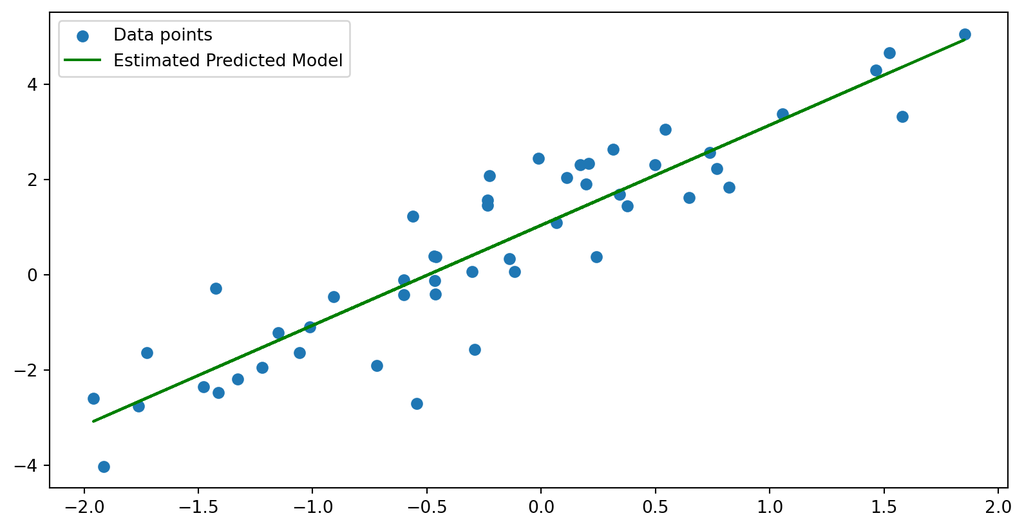

```python
plt.scatter(x = dataset["x"], y = dataset["y"])
plt.plot(dataset["x"], dataset["p_estimated"], color = 'green')

plt.legend(labels = ["Data points","Estimated Predicted Model"])
plt.show()
```

## Try it yourself! 🚀

- How good is the estimated fit?
- Create two overlapping lineplots
- $(x \text{ }$ vs $\text{ } p)$ and $(p_{estimated} \text{ }$ vs $\text{ } p_{estimated})$
- Create a legend to label each plot
- Solution: Appendix 03

## Try it yourself! 🚀

- Compute a column with the formula `sample_error = y - p_estimated`
- Create a `lambda` function `fn_positive_error = lambda error: error >= 0`
- Compute a column for whether the error is positive using `.apply()`
- Solution: Appendix 04

## Try it yourself (last time)! 🚀

- Compute a new column `error_sqr = sample_error ** 2`
- Calculate the mean of `error_sqr`
- Solution: Appendix 05

# That’s all for today! 🎉

# Enjoy the fall break! 🍂

## Appendix 01

- Create a new dataset called `subset_above2`
- Subset records with $y \ge 2$ using `.query()`
- Count the original rows with `len(dataset)`
- Count the subsetted rows: `len(subset_above2)`
- Compute the proportion of subsetted observations

```python
# Create the new dataset
subset_above2 = pd.DataFrame()

# Subset the records with y >= 2
subset_above2 = dataset.query("y >= 2")

# Count the original rows
original_rows = len(dataset)

# Count the subsetted rows
subsetted_rows = len(subset_above2)

# Compute the proportion of subsetted observations
proportion = subsetted_rows / original_rows
proportion
```

```
0.3
```

Back to Exercise 01

## Appendix 02

- Store the sample mean of $y$ as `ybar`
- Compute the standard deviation of $y$ as `stdv_sample`
- Use `.query()` to subset observations that satisfy $abs\left(y - ybar \right) \le stdv\_sample$
- HINT: Use `.mean()` and `.std()`
- HINT: Use the globals `@xbar`, `@stdv_sample`

```python
# Store the sample mean of y as ybar
ybar = dataset["y"].mean()

# Compute the standard deviation of y as stdv_sample
stdv_sample = dataset["y"].std()

# Subset observations that satisfy abs(y - ybar) <= stdv_sample
subset_within_stdv = dataset.query("abs(y - @ybar) <= @stdv_sample")

# Count the subsetted rows
len(subset_within_stdv)
```

```
33
```

Back to Exercise 02

## Appendix 03

- How good is the estimated fit?
- Create two overlapping lineplots
- $(x \text{ }$ vs $\text{ } p)$ and $(p_{estimated} \text{ }$ vs $\text{ } p_{estimated})$
- Create a legend to label each plot

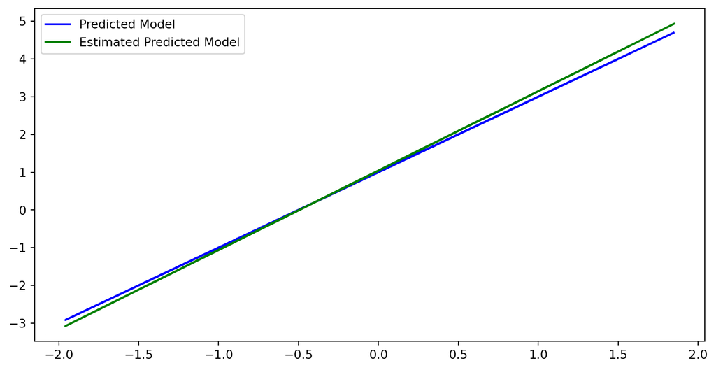

```python
plt.plot(dataset["x"], dataset["p"], color = 'blue')
plt.plot(dataset["x"], dataset["p_estimated"], color = 'green')

plt.legend(labels = ["Predicted Model", "Estimated Predicted Model"])
plt.show()
```

Back to Exercise 03

## Appendix 04

- Compute a column with the formula `sample_error = y - p_estimated`
- Create a `lambda` function `fn_positive_error = lambda error: error >= 0`
- Compute a column for whether the error is positive using `.apply()`

```python
# Compute a column with the formula sample_error = y - p_estimated
dataset["sample_error"] = dataset["y"] - dataset["p_estimated"]

# Create a lambda function fn_positive_error = lambda error: error >= 0
fn_positive_error = lambda error: error >= 0

# Compute a column for whether the error is positive using .apply()
dataset["positive_error"] = dataset["sample_error"].apply(fn_positive_error)
dataset.head(3)
```

|  | x | e | y | p | p_estimated | sample_error | positive_error |
| --- | --- | --- | --- | --- | --- | --- | --- |
| 0 | 0.496714 | 0.324084 | 2.317512 | 1.993428 | 2.085649 | 0.231863 | True |
| 1 | -0.138264 | -0.385082 | 0.338389 | 0.723471 | 0.750241 | -0.411852 | False |
| 2 | 0.647689 | -0.676922 | 1.618455 | 2.295377 | 2.403160 | -0.784705 | False |

Back to Exercise 04

## Appendix 05

- Compute a new column `error_sqr = sample_error ** 2`
- Calculate the mean of `error_sqr`

```python
# Compute a new column error_sqr = sample_error ** 2
dataset["error_sqr"] = dataset["sample_error"] ** 2

# Calculate the mean of error_sqr
mean_error_sqr = dataset["error_sqr"].mean()
mean_error_sqr
```

```
0.7400786858214785
```

Back to Exercise 05

[Linear Models](https://raw.githack.com/danilofreire/qtm151/main/lectures/lecture-12/12-linear-models.html)